# Homework 1: Group 25

1/22/2022

# Case study 1: Audience Size

## 1) Data preparation

### i. Clean & select only the variables of interest

We first import the dataframe name name it “survey_adjusted.” We have used the following code select only variables of interest and rename them as instructed:

```r
survey_adjusted <- survey_original %>%
  rename(age = Answer.Age, gender = Answer.Gender, education = Answer.Education, income = Answer.HouseHoldIncome, sirius = Answer.Sirius.Radio, wharton = Answer.Wharton.Radio, worktime = WorkTimeInSeconds) %>%
  select(age, gender, education, income, sirius, wharton)

survey_adjusted$index <- 1:nrow(survey_adjusted) #add an index column so we can identify the samples later on
```

### ii. Handle missing/wrongly filled values of the selected variables

We will proceed with the following two steps in this process:

1. Eliminate samples with missing or invalid values for “sirius” or “wharton”

   Since our goal is to estimate the audience size of Wharton’s show on Sirius Radio, in the estimation of the audience size, we will only exclude samples with missing or invalid values for one of the following questions:
   - Have you ever listened to Sirius Radio? (“sirius”)
   - Have you ever listened to Sirius Radio by Wharton? (“wharton”)
2. Adjust samples with missing values or incorrect responses if possible

   We will not eliminate any of the samples with missing values or incorrect responses in the following columns:
   - age
   - gender
   - education
   - income

   This is because the missing values or incorrect responses does not affect our goal of estimating the audience size of Wharton’s radio show.

   However, we will look at incorrect responses and see if reasonable adjustments can be made.

   As for samples with missing values, we suspect that it results from the people surveyed not wanting to disclose their personal information, such as age, gender, education, or income. Therefore, these samples are still viable to be used in our estimation of the audience size.

#### 1. Eliminate samples with missing or invalid values for “sirius” or “wharton”

We first look at what unique values are in the columns “sirius” and “wharton” to identify which values, other than blank values, will help us pinpoint which samples should be excluded.

```r
unique(survey_adjusted[c("sirius")])
unique(survey_adjusted[c("wharton")])
```

From the code above, we learned that there are three values for “sirius” and “wharton” in the dataframe survey_adjusted:

1. Yes
2. No
3. (blank)

Therefore, we will exclude all samples with blank values (= 7 samples in total) in either “sirius” or “wharton” columns from our dataset using the following code:

```r
survey_adjusted2 <- survey_adjusted %>%
  filter(sirius!="" & wharton!="")
```

#### 2. Adjust samples with missing values or incorrect responses if possible

We will take different approaches for continuous and categorical variables:

- For continuous variable (age):
  - Look at the distribution to see if there are any outliers or non-numerical values
  - Mark samples with outlier values to be excluded from our analysis of survey respondents’ characteristics
  - Look at non-numerical values and see if they can be adjusted to a numerical value. If that is not possible, mark them to be excluded from our analysis of survey respondents’ characteristics
- For categorical variables (gender, education, income):
  - Look at the unique values of each variable
  - See if any samples’ answers can be adjusted to one of the valid answers (i.e. fixing a typo)
  - Mark samples that cannot adjusted, and those with blank values to be excluded from our analysis of survey respondents’ characteristics

##### 2a. Adjusting continuous variables (age)

**Checking for non-numerical values**

```r
survey_adjusted2 %>%
  mutate(age_numerical = age) %>% #clone a column (age) and create a new one age_numerical
  mutate(age_numerical = as.numeric(age_numerical)) %>% #coerce all values in "age_numerical" to numerical - non-numerical values will be turned into NA
  filter(is.na(age_numerical)) #filter out the samples with non-numerical values in age
  c("age")  #list out the values in "age" for those samples
```

The code above produces the following table:

| age | gender | education | income | sirius | wharton | index | age_numerical |
| --- | --- | --- | --- | --- | --- | --- | --- |
| female | Female | Some college, no diploma; or Associate’s degree | Above $150,000 | Yes | No | 886 | NA |
| Eighteen (18) | Male | High school graduate (or equivalent) | $30,000 - $50,000 | Yes | No | 1008 | NA |
| 27` | Male | Some college, no diploma; or Associate’s degree | Less than $15,000 | No | No | 1535 | NA |

We will make the following adjustments regarding age data of these three samples into the dataframe “survey_adjusted2”

- Change “Eighteen (18)” & “27`” into “18” & “27” respectively.

```r
survey_adjusted2["age"][survey_adjusted2["age"] == "Eighteen (18)"] <- 18
survey_adjusted2["age"][survey_adjusted2["age"] == "27`"] <- 27
```

- Mark the response with “female” inserted as age to be excluded from our analysis of survey respondents’ characteristics. (Although it will be used in our estimation of audience size.)

```r
survey_adjusted2$exclude_respondent_analysis <- "" #add new column to mark exclusion from audience analysis
survey_adjusted2["exclude_respondent_analysis"][survey_adjusted2["age"] == "female"] <- "yes" #mark as excluded
survey_adjusted2["exclude_respondent_analysis"][survey_adjusted2["exclude_respondent_analysis"] != "yes"] <- "no" #include other samples for now
```

```r
survey_adjusted2["exclude_respondent_analysis"][survey_adjusted2["age"] == ""] <- "no"
```

**Checking for outliers**

To check for outliers, we will first visualize the age data into a boxplot.

*Note: we will only look at data with age as numerical numbers.*

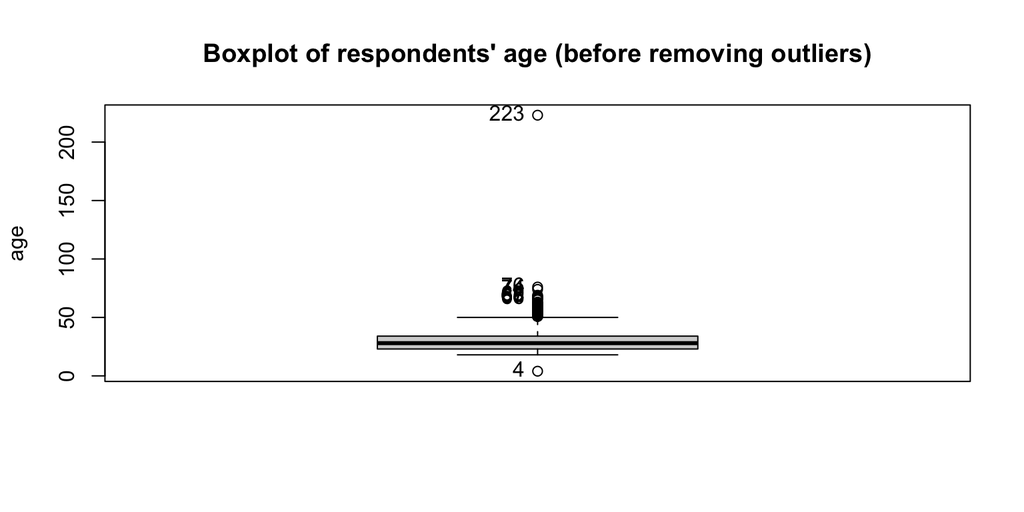

The boxplot of respondents’ age after removing the outliers looks like this:

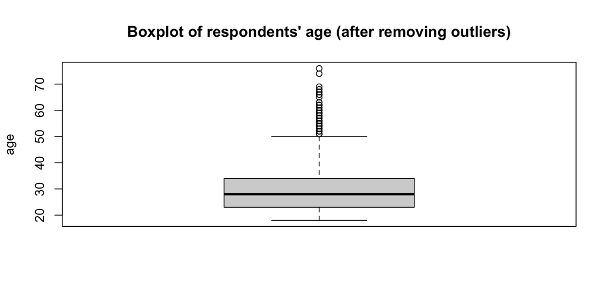

##### 2b. Adjusting categorical variables

We used the following code to see the unique values in responses for “gender” “education” and “income.”

```r
unique(survey_adjusted2[c("gender")])
unique(survey_adjusted2[c("education")])
unique(survey_adjusted2[c("income")])
```

As a result, we found that:

- 6 respondents did not report their gender (blank value)
- 4 respondents did not report their income (blank value)
- 17 respondents did not report their education level (value = “select one”)

Therefore, we will mark these responses so that they will be excluded from our analysis of the respondents’ characteristics

```r
survey_adjusted2["exclude_respondent_analysis"][survey_adjusted2["gender"] == ""] <- "yes"
survey_adjusted2["exclude_respondent_analysis"][survey_adjusted2["income"] == ""] <- "yes"
survey_adjusted2["exclude_respondent_analysis"][survey_adjusted2["education"] == "select one"] <- "yes"
```

To reiterate, we did not adjust any categorical variables, rather we marked samples with invalid values to be excluded from our analysis of the respondents’ characteristics

### iii. Brief summary

This is the summary data of all the variables collected:  
*Remark: we have excluded some data as shown in the previous process from the analysis of survey respondents’ characteristics*

#### Age

The mean of respondents’ age is 30.307, and the standard deviation is 9.874. Below is a histogram showing the age distribution among respondents.

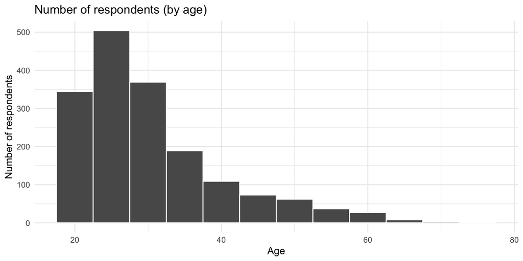

#### Education

Below is a histogram showing the number of respondents by education level.

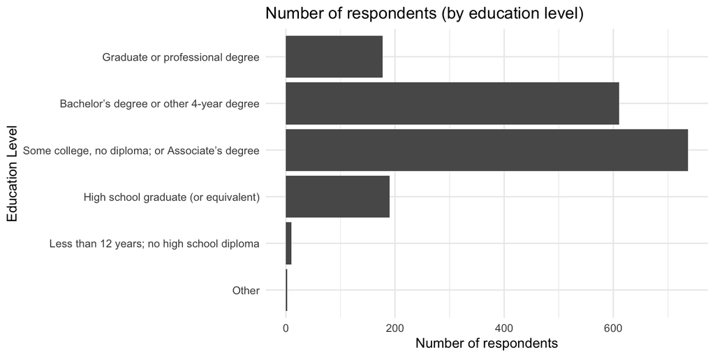

#### Income

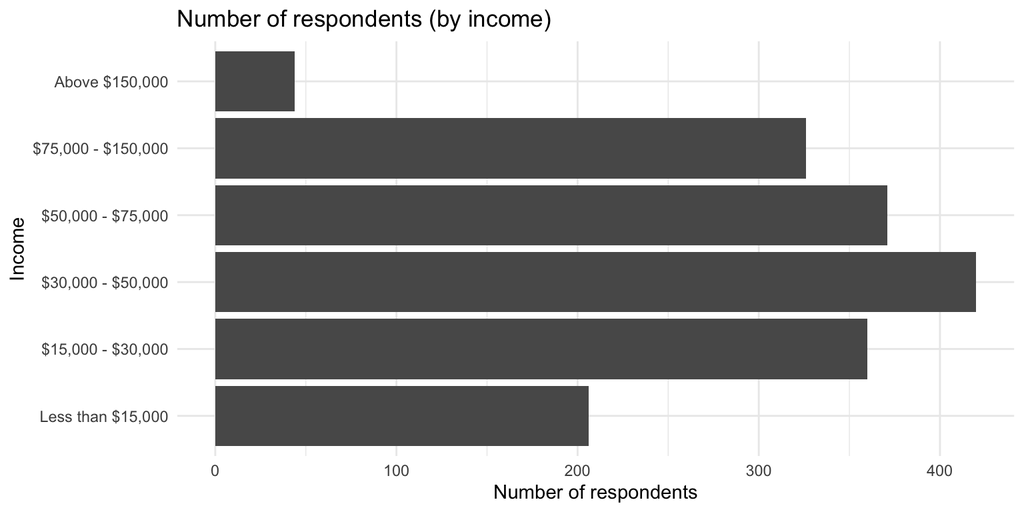

#### Gender

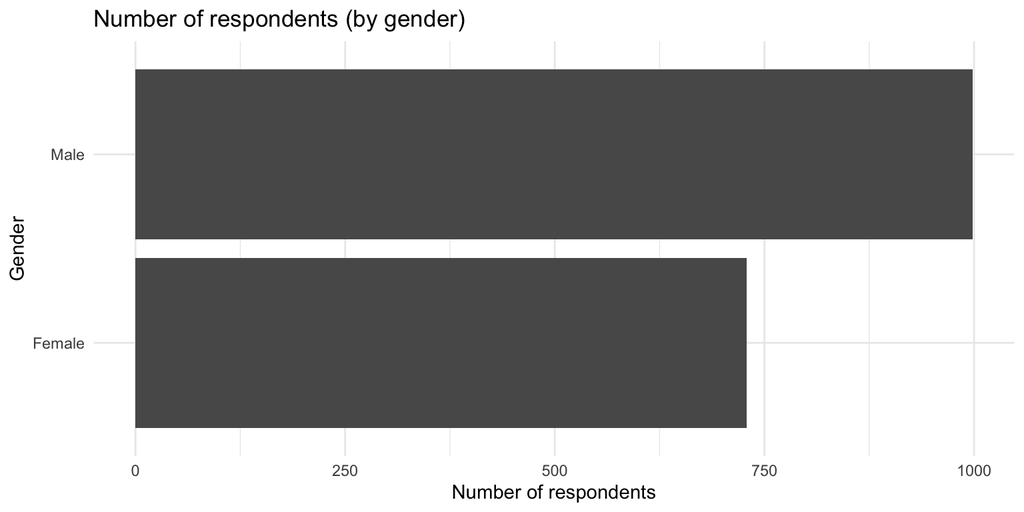

Write a brief report to summarize all the variables collected. Include both summary statistics (including sample size) and graphical displays such as histograms or bar charts where appropriate. Comment on what you have found from this sample. (For example - it’s very interesting to think about why would one work for a job that pays only 10cents/each survey? Who are those survey workers? The answer may be interesting even if it may not directly relate to our goal.)

## 2) Sample properties

1. Does this sample appear to be a random sample from the general population of the USA?
2. Does this sample appear to be a random sample from the MTURK population?

## 3) Final estimate

### 3.1 Goal of the study

The goal of the study is to estimate the audience size of the Business Radio Powered by the Wharton School in Sirius Radio in January 2014.

### 3.2 Method used: data gathering, estimation methods

We have gathered data by using a survey on Amazon Mechanical Turk (MTURK) on May 24, 2014. The main questions of interest in the survey are:

- “Have you ever listened to Sirius Radio”
- “Have you ever listened to Sirius Business Radio by Wharton?”

Our estimation of the audience size of Wharton’s radio program is based on the following assumptions:

- The sampling frame, the people surveyed on MTURK, is representative of the target population, the people living in the US
- A Sirius Radio listener on MTURK is just as likely as a typical Sirius Radio listener to listen to Wharton’s radio program

We estimated the audience size of Wharton’s radio program by:

- Estimating the proportion of Sirius listeners who listen to Wharton’s radio program using the proportion of Wharton radio program listeners to Sirius Radio listeners surveyed
- Multiply that proportion to 51.6 million, the number of Sirius Radio listeners in May of 2014

### 3.3 Findings

We have estimated that the audience size for Business Radio Powered by the Wharton School is **2.66 million people.**

- We have estimated that *p*, the proportion of the Wharton listeners to that of the Sirius listeners, is 5.155%.
- We assumed that the total number of Sirius Radio listeners are 51.6 million people, using the data from May 2014.

*Reference:* We estimated using the dataframe “survey_adjusted2,” used the following code to estimate *p*, expressed in the code below as “wharton_share.”

```r
sirius_audience <- sum(survey_adjusted2$sirius=="Yes")
wharton_audience <- sum(survey_adjusted2$wharton=="Yes")
wharton_share <- wharton_audience/sirius_audience
```

### 3.4 Limitations of the study

Here are the limitations of this study:

1. The number of Sirius Radio listeners could have significantly changed between January and May of 2014
2. The MTURK population might not be representative of the US population
3. The Sirius radio listener population on MTURK might not be representative of all Sirius radio listeners

## 4) New task

# Case Study 3: Major League Baseball

## 4.1 EDA: Relationship between payroll changes and performance

### i. Explain why the log difference is more appropriate in this setup

The log difference is more appropriate because it represents the percentage change in payroll year-on-year. Therefore, it can be used as a standardized yardstick for measurement for all teams.

In contrast, the absolute difference will differ from team to team because the absolute payroll amount of each team is different.

### ii. Create a new variable diff_log

```r
payroll <- wide_modified %>% #turn payroll into long-form
  select(team, p1999:p2014) %>%
  pivot_longer(cols=p1999:p2014,
               names_to = "year",
               names_prefix = "p",
               values_to = "payroll")

payroll <- payroll %>%
  mutate(payroll_log = log(payroll))%>% #create new column "payroll_log"
  group_by(team)%>% #group by team first
  mutate(previous_payroll_log = lag(payroll_log, order_by = year))%>% #Use dlypr::lag, ordering by year
  mutate(diff_log = payroll_log - previous_payroll_log)

diff_log <- payroll %>%
  select(team, year, payroll, payroll_log, diff_log)
```

### iii. Create a long data table

```r
win_pct <- wide_modified %>%
  select(team, X1998.pct:X2014.pct) %>%
  pivot_longer(cols=X1998.pct:X2014.pct,
               names_to = "year",
               names_prefix = "X",
               values_to = "win_pct")%>%
  mutate(year = substr(year, 1,4)) #mutate the year 2XXX.pct by selecting only position 1 to 4 of the string

long_modified <- win_pct %>%  #join the pivoted columns in to a long table
  inner_join(diff_log, by=c("team","year"))
```

## 4.2 Exploratory questions

### i. Which five teams had highest increase in their payroll between years 2010 and 2014, inclusive?

The five teams th the biggest increase in payroll are shown in the table below.

| team | Payroll increase from 2010 to 2014 (%) |
| --- | --- |
| Los Angeles Dodgers | 90.8 |
| Texas Rangers | 90.1 |
| San Diego Padres | 86.9 |
| Pittsburgh Pirates | 80.4 |
| Washington Nationals | 78.5 |

### ii. Between 2010 and 2014, inclusive, which team(s) “improved” the most? That is, had the biggest percentage gain in wins?

The five teams with the biggest percentage gains in win are shown in the table below. Please not that the percentage gain in wins is the difference between win_pct in 2014 and win_pct in 2010.

| team | Percentage gains in wins (2014 vs 2010, in %) |
| --- | --- |
| Pittsburgh Pirates | 19.1 |
| Baltimore Orioles | 18.5 |
| Washington Nationals | 16.7 |
| Seattle Mariners | 16.0 |
| Kansas City Royals | 13.6 |

## 4.3 Do log increases in payroll imply better performance?

Log increases in payroll does not imply better performance. This is because there is low correlation between YoY change in payroll (diff_log) and YoY change in performance (measured by variable “diff_win_pct”, which is win_pct of year n - win_pct of year (n-1)).

The correlation between YoY change in payroll (%) and YoY performance gain/loss is -0.02

The scatterplot between log increases in payroll and winning performance, along with the correlation between the two variables, shown below, supports this conclusion.

### Scatterplot: YoY change in payroll vs. YoY change in performance

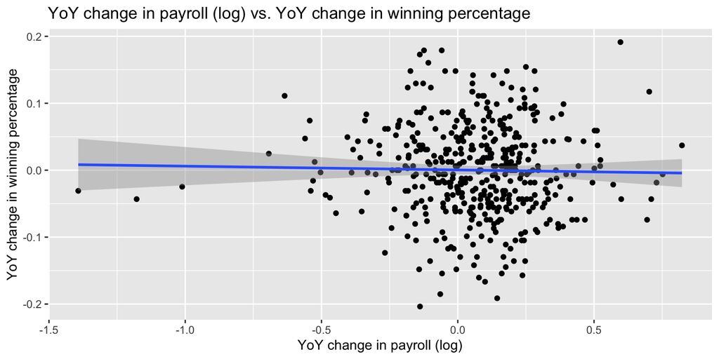

## 4.4 Comparison

Which set of factors are better explaining performance? Yearly payroll or yearly increase in payroll? What criterion is being used?

Yearly payroll is better than explaining performance than yearly increase in payroll. The reason is because it has a higher correlation with performance (win_pct):

- correlation between yearly payroll vs. performance: 0.348
- correlation between yearly increase in payroll vs. performance: 0.145